# Machine Learning Phase 2 Report 2023 sem1

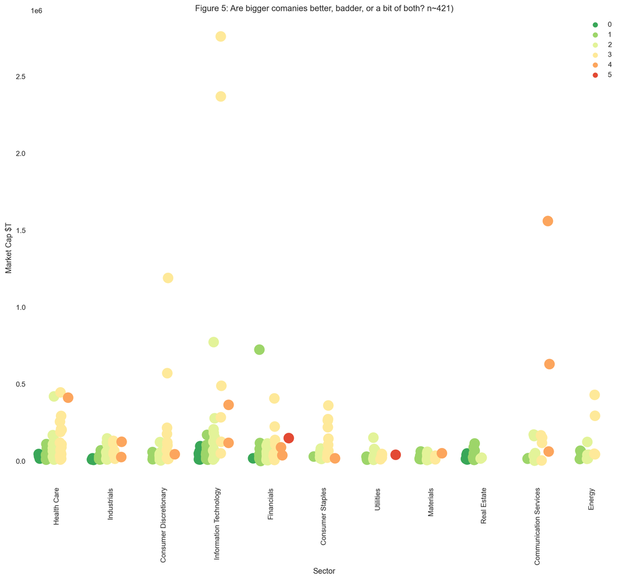

```python
#### Phase 1 Figure 5
# p5 - Is Bigger Badder - what is the relationship between Market Capitalisation and Controversy by Sector?

MarketCapMil = workingData['MarketCap']/1000000

pyplot.rcParams['axes.facecolor'] = 'white'

# Plot Figure

pyplot.figure(figsize = (15,12))

sns.stripplot(y = MarketCapMil, x = workingData['Sector'], hue = workingData['ControversyLevel'], jitter=True,
    dodge=True, palette = trafficLights, size=15 )


# Add labels
pyplot.title('Figure 5: Are bigger comanies better, badder, or a bit of both? n~'+str(sampleSize)+')')
pyplot.legend(loc = 'upper right')
pyplot.ylabel(" Market Cap $T")
pyplot.xticks(rotation=90)
pyplot.show();
```

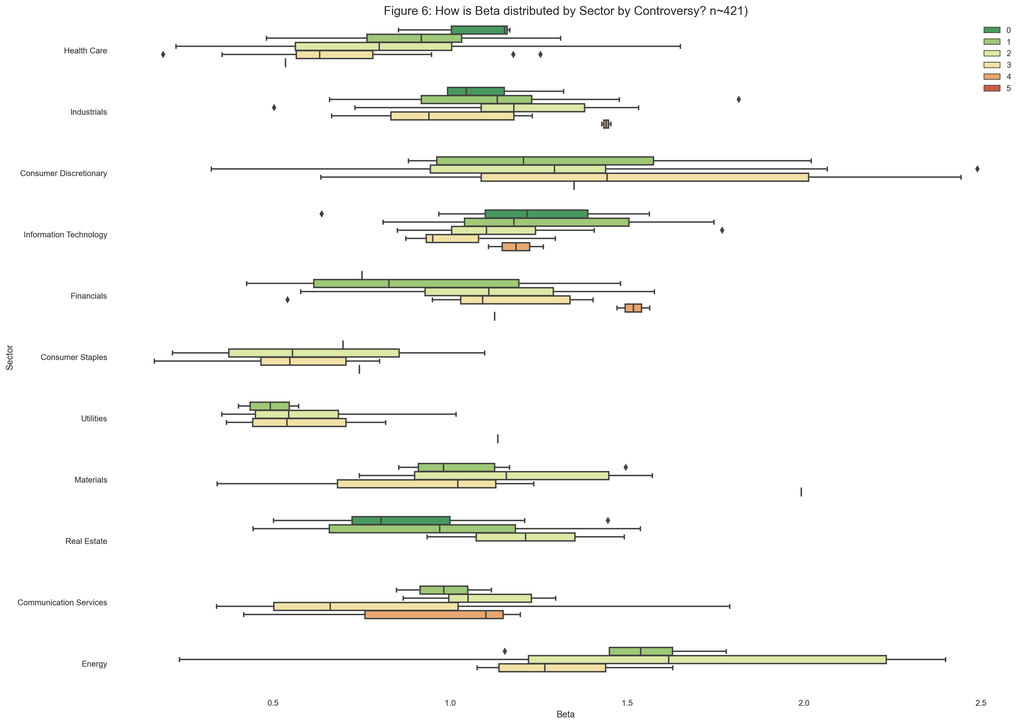

```python
#### Phase 1 Figure 6
# p6 - look at the dipserson of Beta risk as facted by controversy level

# Define plot
pyplot.figure(figsize = (20,15))
sns.boxplot( data = workingData, x = 'Beta', y= 'Sector', hue = 'ControversyLevel', palette = trafficLights)

# Add labels
pyplot.title('Figure 6: How is Beta distributed by Sector by Controversy? n~'+str(sampleSize)+')', fontsize = 15);
pyplot.legend(loc = 'upper right')

pyplot.show();
```

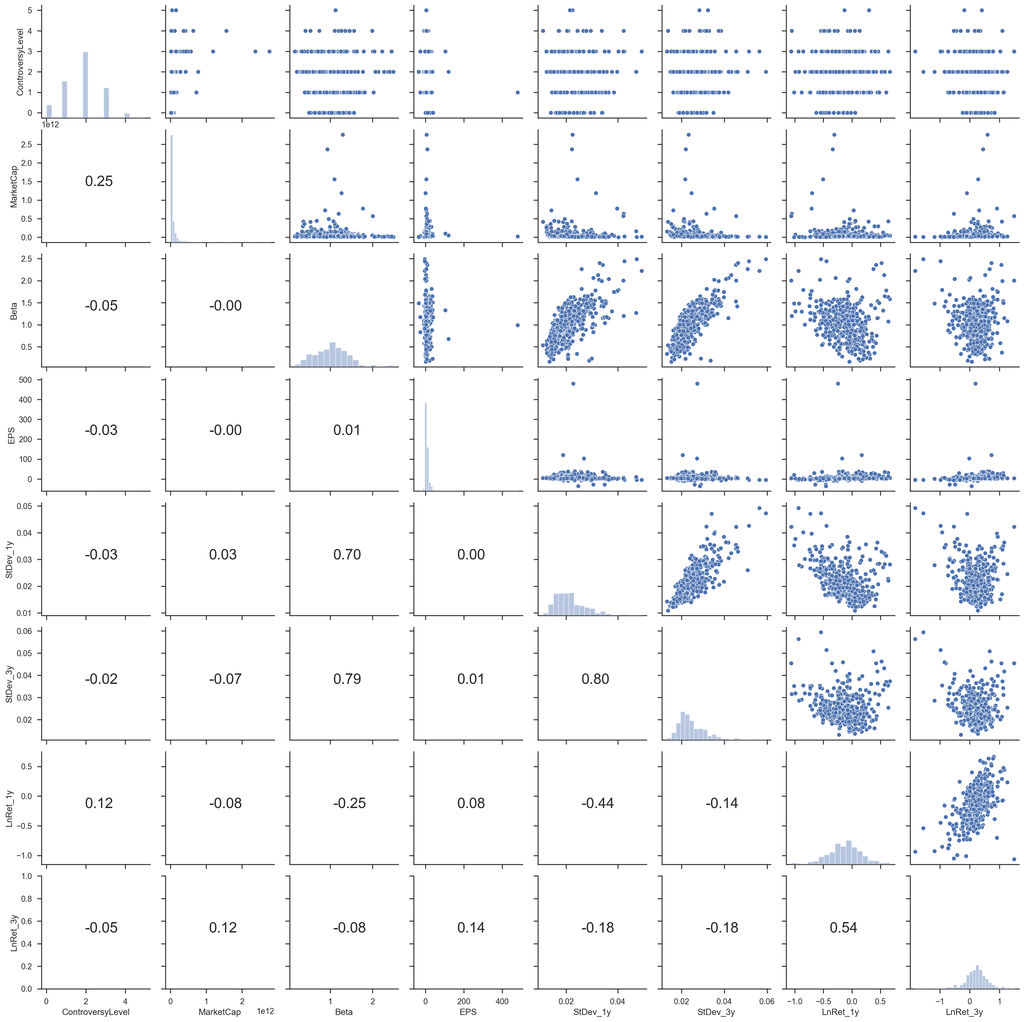

```python
#### Appendix A7 - Phase 1 Pairwise Plot

import matplotlib.pyplot as plt
%matplotlib inline
%config InlineBackend.figure_format = 'retina'
pyplot.style.use('ggplot')
pyplot.rcParams['figure.figsize'] = (10,5)
import seaborn as sns
sns.set(style="ticks", color_codes = True)

# sns.pairplot(
#     X,
#     vars = ['ControversyLevel', 'MarketCap', 'Beta', 'EPS','StDev_1y','StDev_3y','LnRet_1y','LnRet_3y'])


# Adding correlation coefficients to the plot above

import scipy.stats as stats

def corrfunc(x, y, **kws):
    r, _ = stats.pearsonr(x, y)
    ax = pyplot.gca()
    ax.annotate('{:.2f}'.format(r),
                xy=(.4, .5), xycoords = ax.transAxes, fontsize = 20)

g = sns.PairGrid(X, vars = ['ControversyLevel', 'MarketCap', 'Beta', 'EPS','StDev_1y','StDev_3y','LnRet_1y','LnRet_3y'])
g.map_upper(sns.scatterplot)
g.map_lower(corrfunc)
g.map_diag(sns.distplot, kde = False)
pyplot.show();
```

### Appendix B: Summary Statistics on Raw Data

```python
# ANOVA ON SUMMARY STATS

import scipy.stats as stats
import pandas as pd

Sectors = workingData['Sector'].unique()
Sectors

# Create a list of the summary functions you want to apply
summary_functions = ['mean', 'median', 'std', 'count']

# Group by 'Sector' and calculate summary statistics for the selected columns
summary_statistics = df.groupby('Sector')[['MarketCap', 'Beta', 'EPS', 'StDev_1y', 'StDev_3y', 'LnRet_1y', 'LnRet_3y']].agg(summary_functions)
# Extract the mean values for each column and create separate lists for each sector
mean_market_cap = summary_statistics['MarketCap']['mean'].tolist()
mean_beta = summary_statistics['Beta']['mean'].tolist()
mean_eps = summary_statistics['EPS']['mean'].tolist()
mean_stdev_1y = summary_statistics['StDev_1y']['mean'].tolist()
mean_stdev_3y = summary_statistics['StDev_3y']['mean'].tolist()
mean_lnret_1y = summary_statistics['LnRet_1y']['mean'].tolist()
mean_lnret_3y = summary_statistics['LnRet_3y']['mean'].tolist()

# Combine the mean values of all variables into a list of lists
all_means = [mean_market_cap, mean_beta, mean_eps, mean_stdev_1y, mean_stdev_3y, mean_lnret_1y, mean_lnret_3y]

# GET ANOVA mean vals
f_statistic, p_value = stats.f_oneway(*all_means)

# REV results
if p_value < 0.05:
    print(f"Reject the Null hypothesis that all mean values for each variable have the same mean value with a p-value of {round(p_value, 5)}")
else:
    print(f"Fail to reject the Null hypothesis that all mean values for each variable have the same mean value with a p-value of {round(p_value, 5)}")

print(summary_statistics)
```

```
Reject the Null hypothesis that all mean values for each variable have the same mean value with a p-value of 0.0
                           MarketCap                                    \
                                mean        median           std count
Sector
Communication Services  2.210058e+11  1.180000e+11  4.013112e+11    15
Consumer Discretionary  7.253831e+10  2.359260e+10  1.849109e+11    49
Consumer Staples        7.525460e+10  4.150085e+10  8.836397e+10    30
Energy                  7.478834e+10  4.022599e+10  1.067191e+11    19
Financials              6.215596e+10  2.994460e+10  1.082379e+11    59
Health Care             9.072058e+10  4.935427e+10  1.063634e+11    52
Industrials             4.234296e+10  3.211565e+10  3.502281e+10    58
Information Technology  1.703626e+11  4.474510e+10  4.676059e+11    60
Materials               2.580894e+10  2.265008e+10  1.623117e+10    24
Real Estate             2.978149e+10  2.192225e+10  2.505868e+10    28
Utilities               3.310845e+10  2.613476e+10  2.911860e+10    27

                            Beta                                  EPS         \
                            mean    median       std count       mean median
Sector
Communication Services  0.977292  1.002111  0.370561    15   5.354000  3.090
Consumer Discretionary  1.311378  1.330049  0.465094    49  19.591020  4.620
Consumer Staples        0.589291  0.562631  0.245999    30   3.316333  2.785
Energy                  1.517981  1.537649  0.536224    19  12.444737  9.340
Financials              1.040315  1.084095  0.311701    59   7.520508  5.830
Health Care             0.799687  0.789760  0.305381    52   7.790962  5.280
Industrials             1.133338  1.137226  0.256103    58   8.263793  5.915
Information Technology  1.178647  1.166608  0.243869    60   5.573667  4.525
Materials               1.134295  1.083216  0.352218    24   8.439167  7.250
Real Estate             0.935131  0.904820  0.315584    28   4.107857  3.265
Utilities               0.598404  0.536593  0.208378    27   2.932593  3.170

                                         StDev_1y                            \
                              std count      mean    median       std count
Sector
Communication Services   7.660641    15  0.025260  0.021703  0.010230    15
Consumer Discretionary  71.204355    49  0.027055  0.026227  0.007578    49
Consumer Staples         3.189312    30  0.016278  0.015685  0.003159    30
Energy                  10.741075    19  0.026736  0.027051  0.005393    19
Financials               6.824274    59  0.020286  0.020268  0.004012    59
Health Care             10.745589    52  0.020242  0.019867  0.005234    52
```

[output cut: 35 more lines]

```


                             std count
Sector
Communication Services  0.439322    15
Consumer Discretionary  0.579576    49
Consumer Staples        0.244019    30
Energy                  0.294462    19
Financials              0.256384    59
Health Care             0.352328    52
Industrials             0.385776    58
Information Technology  0.398154    60
Materials               0.418187    24
Real Estate             0.246188    28
Utilities               0.159893    27
```

### Appendix C: Models that returned negative R-Square

```python
# APP C: Models that returned negative R-Square
rejected_comp = results_comp[results_comp['R-squared'] <= 0]
rejected_comp
```

|  | Regression Type | Feature Selection Method | Number of Features | R-squared | Mean Abs Err | Legend |
| --- | --- | --- | --- | --- | --- | --- |

### Appendix D: Comprehensive Regression Scoring

```python
results_comp
```

|  | Regression Type | Feature Selection Method | Number of Features | R-squared | Mean Abs Err | Legend |
| --- | --- | --- | --- | --- | --- | --- |
| 126 | Random Forest | Mutual Information | 16 | 0.464443 | 3.764012 | Random Forest Mutual Information |
| 83 | Gradient Boosting | Correlation | 11 | 0.455154 | 3.928863 | Gradient Boosting Correlation |
| 118 | Random Forest | Mutual Information | 15 | 0.453028 | 3.817165 | Random Forest Mutual Information |
| 110 | Random Forest | Mutual Information | 14 | 0.446119 | 3.783694 | Random Forest Mutual Information |
| 75 | Gradient Boosting | Correlation | 10 | 0.433112 | 4.002464 | Gradient Boosting Correlation |
| ... | ... | ... | ... | ... | ... | ... |
| 12 | Linear | Mutual Information | 2 | 0.072848 | 5.231774 | Linear Mutual Information |
| 117 | Decision Tree | Mutual Information | 15 | 0.072371 | 5.087059 | Decision Tree Mutual Information |
| 15 | Gradient Boosting | Mutual Information | 2 | 0.056382 | 5.343663 | Gradient Boosting Mutual Information |
| 22 | Random Forest | Mutual Information | 3 | 0.040114 | 5.162353 | Random Forest Mutual Information |
| 4 | Linear | Mutual Information | 1 | 0.007417 | 5.641932 | Linear Mutual Information |

116 rows × 6 columns

### Appendix E: Feature Importance for Random Forest Models

```python
# TABLE OF EACH MODELS RELATIVE IMPORTANCE: RF
rf_feat_ALL
```

| Feature | Importance_rf_mi | Importance_rf_gs | Importance_rf_rs |
| --- | --- | --- | --- |
| ControversyLevel | 0.050231 | 0.067097 | 0.072175 |
| MarketCap | 0.000000 | 0.065919 | 0.079815 |
| Beta | 0.026178 | 0.079318 | 0.081938 |
| EPS | 0.025518 | 0.134453 | 0.128213 |
| StDev_1y | 0.000000 | 0.112496 | 0.112327 |
| StDev_3y | 0.077755 | 0.135212 | 0.127105 |
| LnRet_1y | 0.080308 | 0.018221 | 0.019482 |
| LnRet_3y | 0.104409 | 0.007982 | 0.006565 |
| Sector_Consumer Discretionary | 0.033894 | 0.084514 | 0.086164 |
| Sector_Consumer Staples | 0.043281 | 0.009541 | 0.006492 |
| Sector_Energy | 0.050712 | 0.007631 | 0.005275 |
| Sector_Financials | 0.000000 | 0.022345 | 0.024820 |
| Sector_Health Care | 0.000000 | 0.067986 | 0.068360 |
| Sector_Industrials | 0.006822 | 0.018562 | 0.017238 |
| Sector_Information Technology | 0.065503 | 0.116840 | 0.111788 |
| Sector_Materials | 0.021124 | 0.051882 | 0.052243 |

### Appendix F: Feature Importance for Gradient Boosting Models

```python
# TABLE OF EACH MODELS RELATIVE IMPORTANCE: GB
gb_feat_ALL
```

| Feature | Importance_gb_cr | Importance_gb_gs | Importance_gb_rs |
| --- | --- | --- | --- |
| ControversyLevel | 0.041888 | 0.090500 | 0.090500 |
| MarketCap | 0.000000 | 0.213824 | 0.213824 |
| Beta | 0.027364 | 0.138830 | 0.138830 |
| EPS | 0.025315 | 0.033269 | 0.033269 |
| StDev_1y | 0.000000 | 0.024282 | 0.024282 |
| StDev_3y | 0.077467 | 0.125945 | 0.125945 |
| LnRet_1y | 0.079325 | 0.037879 | 0.037879 |
| LnRet_3y | 0.106678 | 0.088103 | 0.088103 |
| Sector_Consumer Discretionary | 0.037466 | 0.022474 | 0.022474 |
| Sector_Consumer Staples | 0.048854 | 0.132045 | 0.132045 |
| Sector_Energy | 0.044027 | 0.092849 | 0.092849 |

## References

1. Aroussi, R. (n.d.). yfinance: Yahoo! Finance market data downloader. [online] PyPI. Available at: https://pypi.org/project/yfinance/.
2. Brownlee, J. (2019). How to Choose a Feature Selection Method For Machine Learning - MachineLearningMastery.com. [online] MachineLearningMastery.com. Available at: https://machinelearningmastery.com/feature-selection-with-real-and-categorical-data/ [Accessed 26 Jun. 2023].
3. finance.yahoo.com. (2022). Example of Environment, Social and Governance (ESG) Ratings via Yahoo Finance (AAPL). [online] Available at: https://finance.yahoo.com/quote/AAPL/sustainability?p=AAPL Example of url used against all SP500 symbols.
4. MSCI (2023). GICS - Global Industry Classification Standard. [online] www.msci.com. Available at: https://www.msci.com/our-solutions/indexes/gics.
5. Rudden, K. (2019). Scraping ESG Scores. [online] www.kylerudden.com. Available at: https://www.kylerudden.com/blog/scraping-esg-scores/ [Accessed 9 May 2023].
6. Sullivan, K., Bujno, M., Sullivan, K. and Bujno, M. (2023). Emerging trends in ESG governance for 2023. [online] The Harvard Law School Forum on Corporate Governance. Available at: https://corpgov.law.harvard.edu/2023/03/26/emerging-trends-in-esg-governance-for-2023/ [Accessed 10 Apr. 2023].
7. Sustainalytics (2021). ESG Risk Ratings - Methodology Abstract Version 2.1. [online] Available at: https://www.sustainalytics.com/docs/knowledgehublibraries/default-document-library/sustainalytics_esg-risk-rating_methodology-abstract-(2).pdf?sfvrsn=15b2cba1_0 [Accessed 18 Apr. 2023].
8. Sustainalytics (n.d.). Overview of Sustainalytics’ ESG Risk Ratings. [online] Available at: https://connect.sustainalytics.com/hubfs/SFS/Sustainalytics%20ESG%20Risk%20Ratings_Issuer%20Backgrounder.pdf.
9. sustainalytics.com. (n.d.). ESG Risk Ratings. [online] Available at: https://www.sustainalytics.com/esg-data.
10. www.spglobal.com. (2023). S&P 500® - S&P Dow Jones Indices. [online] Available at: https://www.spglobal.com/spdji/en/indices/equity/sp-500/#data.